# Python Final Project Submission

## Customer Churn Prediction

### Ujjwal Murarka

# 1. Summary, background, and value proposition

### Summary

- The project evaluates a sample dataset of ~7,000 telecom customers from Q2-2022 to understand and predict customer churn
- The key stakeholders include the CEO, COO, Chief Customer Officer, or Chief Marketing Officer
- Each row of data captures the demographics, services used by the customer, payment and contract types, and status (churned, joined, or stayed)

#### Key takeaways from the analysis:

- We have identified that customers with *monthly contracts, high monthly charge, subscription to Fiber Optic internet service, and those that are of higher age and unmarried status* are more likely to churn
- The cluster exercise has resulted in 3 customer segments: `the flaky customer`, `the basic customer`, and `the champion customer` (described in the data analysis section)
- We have conducted exploratory data analysis, decision tree and XGB classification models, and customer segmentation through K-Means clusterign
- The XGB classification model developed below has an out-of-sample accuracy of `83%`, while the decision tree model has an accuracy of `82%`

### Value Proposition

- Customer retention is key to the success of a B2C businesses, such as Telecom. Use to data to predict customer churn and increase retention can save millions of dollars spent on customer acquisition
- However, studying this is phenomenon is challenging given there are multiple moving parts including competitor response, variability of human behaviour, biased reporting of reasons for churn, etc.
- Access to their own customer data is the biggest competitive advantage a business has that their competitors cannot replicate
- Businesses can turn their competitive advantage into successful strategy by using the data to make smarter decisions vs. the competition
- Such data analysis can also be used to perform customer persona assessments, create tailored marketing content, develop customer acquisition strategies, etc.

### Background

- **Maping the data landscape:**
  - `Data that exists`: Customer demographics, use of services, costs and payments
  - `Data that might exist`: Customer feedback about the service across different social media and review platforms
  - `Data that probably doesn't exist but could be useful`: Customer interactions with other competitors, customers search history, etc.

### Background (contd.)

- **Day in the life of data:**
  - `Customer acquisition`: Generates a customer ID, captures the source of customer (referral, Facebook, TV or Radio advertisement, etc.), captures the demographics of the customer through the intake form
  - `Customer operations`: captures the services being utilized by the customer. This stage should also be capturing any changes in the services over time. Customer operations potentially captures the active status of the customer as well. Additional data at this stage could be the call or service performance data i.e., number of call drops, average connectivity for the custoemrs,
  - `Billing and finance`: captures the monthly charges, total revenue, extra charges, payment method, etc. Finance could also request a credict check on the customer
  - `Marketing`: This stage would keep track of the offers and promotions going out to the customers, and customers response to those promotions

# 2. Data acquisition and preprocessing

### Source of the dataset

The dataset is taken from the Maven Churn Challenge  
https://www.mavenanalytics.io/blog/maven-churn-challenge

### Reading the data file

```python
data_file_path = pathlib.Path('./data/telecom_customer_churn.csv')
raw_df = pd.read_csv(data_file_path)
raw_df.head()
print('The dataset has {} rows and {} columns'.format(raw_df.shape[0],raw_df.shape[1]))
```

[output not shown]

5 rows × 38 columns

```
The dataset has 7043 rows and 38 columns
```

### Preprosessing the data

1. Dropping columns that are not of interest
   - Customer ID, Number of Dependents, City, Zip Code, Latitude, Longitude, Number of Referrals, Offer, Avg Monthly Long Distance Charges, Avg Monthly GB Download, Total Refunds, Total Extra Data Charges, Total Long Distance Charges, Churn Category, Churn Reason
2. Renaming the remaining columns
   - Standardizing the format of the column names
3. Handling missingness
   - Given most missing values are for the services used, we are assuming service was not availed
4. Mapping Churn status to 0,1
   - Creating the dependent variable column to indicate whether or not the customer churned

#### Cleaned dataset after dropping columns and renaming

```python
cleaned_df.head()
```

|  | gender | age | married | tenure | phone_service | multiple_lines | internet_service | internet_type | online_service | online_backup | ... | streaming_movies | streaming_music | unlimited_data | contract | paperless_billing | payment_method | monthly_charge | total_charges | total_revenue | churn |
| --- | --- | --- | --- | --- | --- | --- | --- | --- | --- | --- | --- | --- | --- | --- | --- | --- | --- | --- | --- | --- | --- |
| 0 | Female | 37 | Yes | 9 | Yes | No | Yes | Cable | No | Yes | ... | No | No | Yes | One Year | Yes | Credit Card | 65.6 | 593.30 | 974.81 | Stayed |
| 1 | Male | 46 | No | 9 | Yes | Yes | Yes | Cable | No | No | ... | Yes | Yes | No | Month-to-Month | No | Credit Card | -4.0 | 542.40 | 610.28 | Stayed |
| 2 | Male | 50 | No | 4 | Yes | No | Yes | Fiber Optic | No | No | ... | No | No | Yes | Month-to-Month | Yes | Bank Withdrawal | 73.9 | 280.85 | 415.45 | Churned |
| 3 | Male | 78 | Yes | 13 | Yes | No | Yes | Fiber Optic | No | Yes | ... | Yes | No | Yes | Month-to-Month | Yes | Bank Withdrawal | 98.0 | 1237.85 | 1599.51 | Churned |
| 4 | Female | 75 | Yes | 3 | Yes | No | Yes | Fiber Optic | No | No | ... | No | No | Yes | Month-to-Month | Yes | Credit Card | 83.9 | 267.40 | 289.54 | Churned |

5 rows × 23 columns

#### Evaluating and handling missingness of data

Since most of the missing values are for the services used by the customers, we are assuming that missing values imply the service was not being used by the customer. Hence, we replace the missing values with `No`

```python
pd.DataFrame({'columns': list(cleaned_df.columns),
              'missing_values': cleaned_df.isna().sum(),
              'dtypes': cleaned_df.dtypes
             }
            ).reset_index(drop = True)
```

|  | columns | missing_values | dtypes |
| --- | --- | --- | --- |
| 0 | gender | 0 | object |
| 1 | age | 0 | int64 |
| 2 | married | 0 | object |
| 3 | tenure | 0 | int64 |
| 4 | phone_service | 0 | object |
| 5 | multiple_lines | 682 | object |
| 6 | internet_service | 0 | object |
| 7 | internet_type | 1526 | object |
| 8 | online_service | 1526 | object |
| 9 | online_backup | 1526 | object |
| 10 | device_protection | 1526 | object |
| 11 | prem_support | 1526 | object |
| 12 | streaming_tv | 1526 | object |
| 13 | streaming_movies | 1526 | object |
| 14 | streaming_music | 1526 | object |
| 15 | unlimited_data | 1526 | object |
| 16 | contract | 0 | object |
| 17 | paperless_billing | 0 | object |
| 18 | payment_method | 0 | object |
| 19 | monthly_charge | 0 | float64 |
| 20 | total_charges | 0 | float64 |
| 21 | total_revenue | 0 | float64 |
| 22 | churn | 0 | object |

#### Mapping the churn status to 0,1

Currently, the values in `churn` column are 'churned', 'stayed', or 'joined'. Since, we are trying to predict whether a customer will churn, we create a new column called `churn_status` that indicates 0 for not churned and 1 for churned.

```python
cleaned_df = cleaned_df.assign(churn_status = cleaned_df.churn.apply(lambda x: 1 if x == 'Churned' else 0))
cleaned_df.churn_status = cleaned_df.churn_status.astype('category')
cleaned_df.churn_status.value_counts()
cleaned_df.drop(['churn'],axis = 1, inplace = True)
```

[output not shown]

# 3. Data visualization

### Corrrelation of churn with other relevant variables

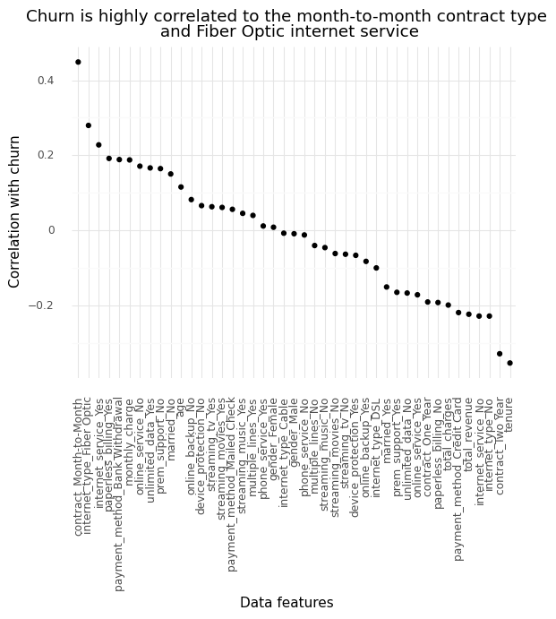

```python
plot_corr
```

### Churn status by contract type

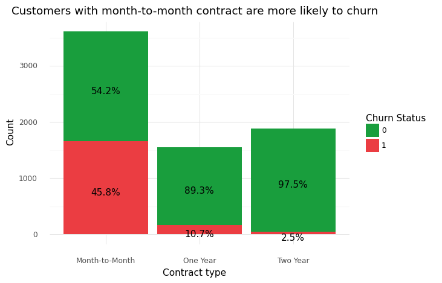

```python
plot_contract
```

### Churn by internet type

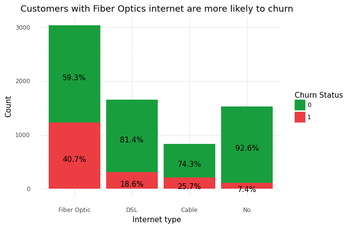

```python
plot_internet_type
```

### Churn density by the monthly charge

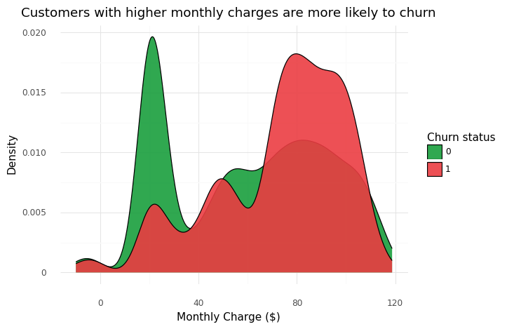

```python
plot_monthly_charge
```

### Variation of monthly charges with internet type

Fiber optics customers have a higher monthly charge. Hence, we see high churn for both customers of fiber optics and those with high monthly charge.

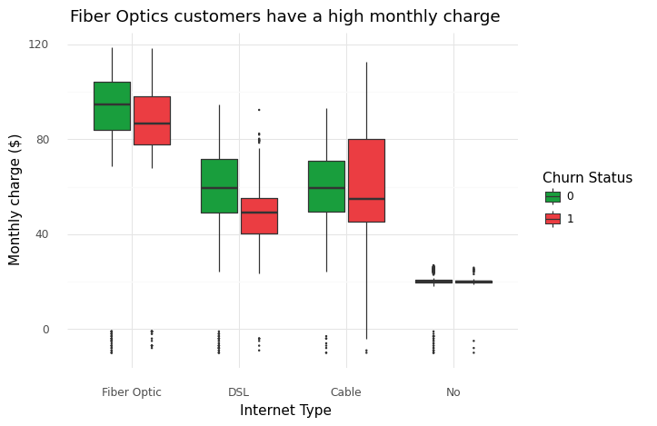

```python
plot_fiber_charge
```

# 4. Data analysis

### Setting up the variable matrices

```python
# Creating the X and y matrices. We are not using the patsy dmatrices method given the large number of predictor variables.
y = cleaned_df.iloc[:,-1]
X = pd.get_dummies(cleaned_df.iloc[:,:-1]) #get_dummies helps convert the discrete variables to 0s and 1s
```

## A. Decision Tree

```python
# Creating a parameter grid for the model tuning
param_grid = {
    'max_leaf_nodes' : [5, 10, 15, 20, 25, 30, 35, 40],
    'min_samples_leaf' : [1, 4, 9, 16, 25, 36, 49]
}

# Defining the base model for the cross validation
tree_model = sklearn.tree.DecisionTreeClassifier()
```

```python
# Running the grid search with 10 fold cross validation
tree_gridsearch = sklearn.model_selection.GridSearchCV(
    tree_model,
    param_grid = param_grid,
    cv = 10
)
```

```python
# Fitting the grid search to the data
tree_gridsearch.fit(X, y)
```

```
GridSearchCV(cv=10, estimator=DecisionTreeClassifier(),
             param_grid={'max_leaf_nodes': [5, 10, 15, 20, 25, 30, 35, 40],
                         'min_samples_leaf': [1, 4, 9, 16, 25, 36, 49]})
```

### Visualizing the performance of the gridsearch for Decision Tree

- The performance of the model intially improves with max_leaf_nodes and then starts detereorating after ~20 nodes
- Moderate min_sample_leafs (~25) perform better than lower or higher minimum samples per leaf

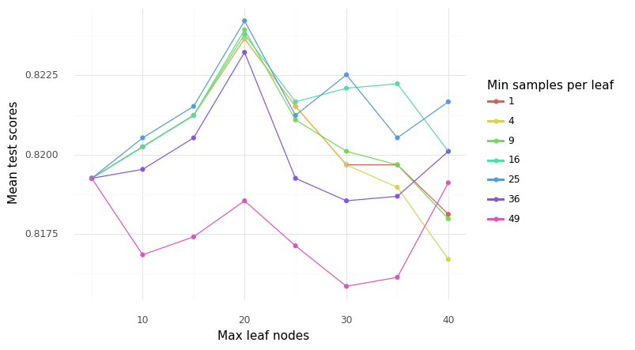

```python
plot_tree_cv_perf
```

### Testing the out-of-sample accuracy of the best decision tree model

```python
# Getting the best decision tree
tree_best = tree_gridsearch.best_estimator_
```

```python
# Splitting the data to get the train (75%) and test set (25%)
X_train, X_test, y_train, y_test = sklearn.model_selection.train_test_split(X, y, test_size = 0.25, random_state = 99)
tree_best.fit(X_train, y_train)
```

```
DecisionTreeClassifier(max_leaf_nodes=20, min_samples_leaf=25)
```

```python
# Getting the accuracy score for out-of-sample data
tree_best_accuracy = sklearn.metrics.accuracy_score(y_test, tree_best.predict(X_test))
print('The out-of-sample accuracy of the decision tree model is {:.2%}'.format(tree_best_accuracy))
```

```
The out-of-sample accuracy of the decision tree model is 81.71%
```

### Top 10 features of the decision tree model

- Month to month contract type and Fiber Optic internet service are among the top 10 features for the model
- Need to further investigate the relationship of age with churn in the next steps

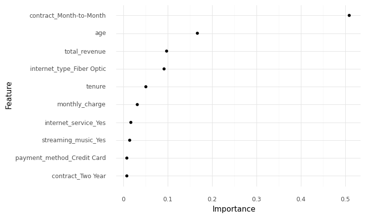

```python
plot_tree_top10_feature
```

## B. XGB Classifier

```python
# Creating a parameter grid to tune the XGB model
param_grid = {
    'max_depth': range (5, 20, 5),
    'n_estimators': range(50, 200, 50),
    'learning_rate': [.001, .01, .1]
}
```

```python
# Setting up a base XGB classifier model
xgb_model = xgb.XGBClassifier()

# Gridsearch for the best xgb model with 5 fold cross-validation
xgb_gridsearch = sklearn.model_selection.GridSearchCV(xgb_model,
                                                      param_grid = param_grid,
                                                      cv = 5,
                                                      n_jobs=-1
                                                     )

# Fitting the gridsearch to the data
xgb_gridsearch.fit(X,y)
```

```
GridSearchCV(cv=5,
             estimator=XGBClassifier(base_score=None, booster=None,
                                     callbacks=None, colsample_bylevel=None,
                                     colsample_bynode=None,
                                     colsample_bytree=None,
                                     early_stopping_rounds=None,
                                     enable_categorical=False, eval_metric=None,
                                     feature_types=None, gamma=None,
                                     gpu_id=None, grow_policy=None,
                                     importance_type=None,
                                     interaction_constraints=None,
                                     learning_rate=None,...
                                     max_cat_threshold=None,
                                     max_cat_to_onehot=None,
                                     max_delta_step=None, max_depth=None,
                                     max_leaves=None, min_child_weight=None,
                                     missing=nan, monotone_constraints=None,
                                     n_estimators=100, n_jobs=None,
                                     num_parallel_tree=None, predictor=None,
                                     random_state=None, ...),
             n_jobs=-1,
             param_grid={'learning_rate': [0.001, 0.01, 0.1],
                         'max_depth': range(5, 20, 5),
                         'n_estimators': range(50, 200, 50)})
```

### Visualizing the performance of the gridsearch for XGB

- Model performance is best at max depth of 5, learning rate of 0.1, and 50 estimators
- The performance detereorates on further increase in the parameters

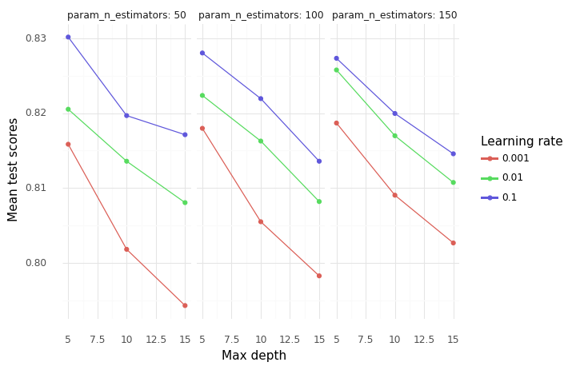

```python
plot_xgb_cv_perf
```

### Testing the out-of-sample accuracy of the best XGB model

```python
# Getting the best estimator model from the gridsearch
xgb_best = xgb_gridsearch.best_estimator_
```

```python
# Getting the accuracy for the out-of-sample data
xgb_best_accuracy = sklearn.metrics.accuracy_score(xgb_best.predict(X_test), y_test)
print('The out-of-sample accuracy of the best xgb model is {:.2%}'.format(xgb_best_accuracy))
```

```
The out-of-sample accuracy of the best xgb model is 82.74%
```

### Top 10 features of the XGB model

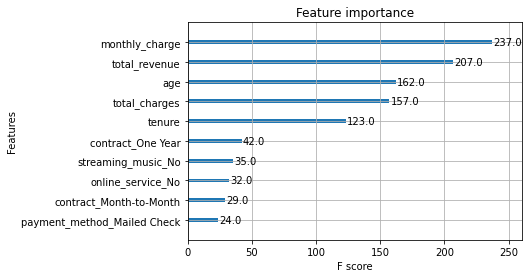

```python
xgb.plot_importance(xgb_best, max_num_features=10)
```

## C. Customer segmentation

In this section, we will use PCA analysis to get 5 components that can explain 50%+ variance of the data. Then we will use K-Means clustering on a normalized dataset with one hot encoding for categorical variables. We identify 3 clusters evaluate the characteristics and % churn in each cluster.

### Code for the PCA and Clustering

```python
scaler = sklearn.preprocessing.MinMaxScaler()
```

```python
col_names = ['age', 'tenure', 'monthly_charge', 'total_charges','total_revenue']
scaled_df = pd.DataFrame(scaler.fit_transform(cleaned_df[col_names]), columns = col_names)
```

```python
cat_df = pd.get_dummies(cleaned_df[cleaned_df.columns[~cleaned_df.columns.isin(col_names)]])
```

```python
cat_df_drop_cols = ['gender_Female', 'married_No', 'phone_service_No', 'multiple_lines_No', 'internet_service_No',
                    'online_service_No', 'online_backup_No','device_protection_No', 'prem_support_No',
                    'streaming_tv_No', 'streaming_movies_No', 'streaming_music_No', 'unlimited_data_No',
                    'paperless_billing_No']
cat_df = cat_df.drop(cat_df_drop_cols, axis = 1)
```

```python
cluster_df = pd.concat([cat_df,scaled_df], axis=1)
```

### Code for the PCA and Clustering (PCA)

```python
pca = sklearn.decomposition.PCA(n_components=5, random_state=19103)
principal_component = pca.fit_transform(cluster_df)
```

```python
pca.explained_variance_ratio_
```

```
array([0.21616299, 0.15093639, 0.07788852, 0.06400562, 0.04942468])
```

```python
PCA_component = principal_component
```

### Code for the PCA and Clustering (Checking for # of clusters)

Based on the below elbow method chart for selection of the number of clusters, we are selecting 3 clusters for our analysis.

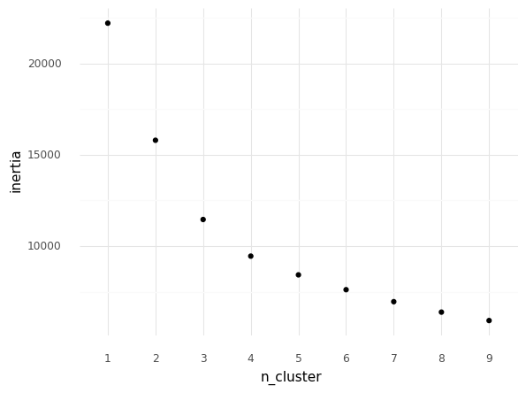

```python
plot_elbow
```

### Customer Personas

`Cluster 1 - Flaky customer`: ~48 year old, mostly unmarried, uses about 5 services including phone and fiber optics, and spends ~USD70 per month engaging in monthly contracts

- Churn in this group was highest at 54%

`Cluster 2 - Basic customer`: ~43 year old, primarily use the phone service with very low monthly charge of ~USD 21

- Churn in this group was ~7%

`Cluster 3 - Champion customer`: ~47 year old, married, high value customer with monthly charges of ~USD83, and uses ~8 services including Fiber Optic

- Chrun in this group was ~7%

### Customer persona data

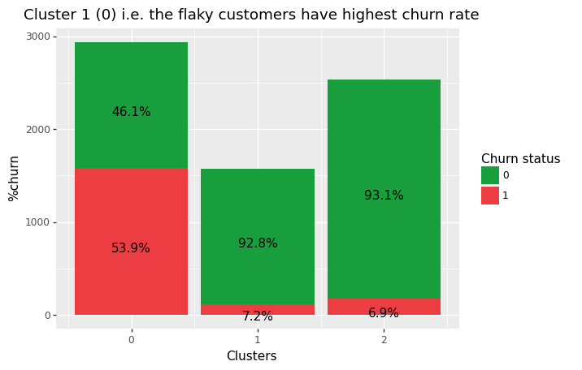

```python
plot_cluster_churn
```

### Customer persona data (contd)

```python
cluster_summary_df
```

| cluster | cluster | pct_churn | age | tenure | monthly_charge | n_services | gender_male | married | phone_service | paperless_billing | monthly_contract | fiber_optic |
| --- | --- | --- | --- | --- | --- | --- | --- | --- | --- | --- | --- | --- |
| 0 | 2935 | 0.538671 | 47.934923 | 16.388756 | 69.862624 | 4.963203 | 0.502555 | 0.323680 | 0.881772 | 0.718569 | 0.938330 | 0.601704 |
| 1 | 1575 | 0.071746 | 43.013968 | 30.259048 | 21.377429 | 1.274286 | 0.509841 | 0.475556 | 0.991111 | 0.287619 | 0.340317 | 0.005714 |
| 2 | 2533 | 0.069088 | 47.031978 | 52.246743 | 82.586380 | 7.840900 | 0.504145 | 0.672325 | 0.873273 | 0.635215 | 0.126332 | 0.497434 |

# 5. Next Steps

The **next steps** for the analysis would include:

- Monitoring the performance of models and updating them for subsequent time-periods
- Augmenting other customer data including complaints, number of queries or calls to the call center, phone and internet performance, etc. to enhance the predictive model
- Leveraging the customer segmentation to develop persona specific telecom plans and marketing campaign
- We will develop a live dashboard of the performance across the segments and improvements from the marketing campaigns

These steps will significantly enhance customer retention and reduce the operating expenses.

### Next steps (contd)

However, there will additional resources required in-terms of both man-power and infrastructure:

- `Talent requirements`: 2 data-scientists(USD200K/year each), 1 business analyst (USD120K/year), 1 program manager (UD220K/year)
- `Infrastructure requirements`: 1 integrated data-server, 4 high-end PCs with at-least 16GB of RAM and intel Core i9 processors